# Introduction to RNAseq analysis in R

November 2024

## Annotation using `AnnotationHub`

- AnnotationHub is web resource of reference materials maintained by the Bioconductor community
- It provides a central location from where genomic reference data (e.g., FASTA, GTF, bed) can be downloaded
- It included references from standard locations (e.g., UCSC, Ensembl)
- The resource includes metadata about each resource e.g., a textual description, tags, and date of modification
- The `AnnotationHub` package creates and manages a local cache of files, helping with quick and reproducible access.

## Annotation using `AnnotationHub`

- Create an annotationhub instance

```r
library(AnnotationHub)

ah <- AnnotationHub()
ah
```

```
## AnnotationHub with 67229 records
## # snapshotDate(): 2022-04-25
## # $dataprovider: Ensembl, BroadInstitute, UCSC, ftp://ftp.ncbi.nlm.nih.gov/g...
## # $species: Homo sapiens, Mus musculus, Drosophila melanogaster, Bos taurus,...
## # $rdataclass: GRanges, TwoBitFile, BigWigFile, EnsDb, Rle, OrgDb, ChainFile...
## # additional mcols(): taxonomyid, genome, description,
## #   coordinate_1_based, maintainer, rdatadateadded, preparerclass, tags,
## #   rdatapath, sourceurl, sourcetype
## # retrieve records with, e.g., 'object[["AH5012"]]'
##
##              title
##   AH5012   | Chromosome Band
##   AH5013   | STS Markers
##   AH5014   | FISH Clones
##   AH5015   | Recomb Rate
##   AH5016   | ENCODE Pilot
```

## Annotation using `AnnotationHub`

- Query AnnotationHub to find the resource we need

```r
ahQueryResult <- query(ah, c("EnsDb", "Mus musculus", "102"))
ahQueryResult
```

```
## AnnotationHub with 1 record
## # snapshotDate(): 2023-04-25
## # names(): AH89211
## # $dataprovider: Ensembl
## # $species: Mus musculus
## # $rdataclass: EnsDb
## # $rdatadateadded: 2020-10-27
## # $title: Ensembl 102 EnsDb for Mus musculus
## # $description: Gene and protein annotations for Mus musculus based on Ensem...
## # $taxonomyid: 10090
## # $genome: GRCm38
## # $sourcetype: ensembl
## # $sourceurl: http://www.ensembl.org
## # $sourcesize: NA
## # $tags: c("102", "AHEnsDbs", "Annotation", "EnsDb", "Ensembl", "Gene",
## #   "Protein", "Transcript")
## # retrieve record with 'object[["AH89211"]]'
```

## Annotation using `AnnotationHub`

- Retrieve the data base and extract gene annotations

```r
MouseEnsDb <- ahQueryResult[[1]]
annotations <- genes(MouseEnsDb, return.type = "data.frame")

colnames(annotations)
```

```
##  [1] "gene_id"              "gene_name"            "gene_biotype"
##  [4] "gene_seq_start"       "gene_seq_end"         "seq_name"
##  [7] "seq_strand"           "seq_coord_system"     "description"
## [10] "gene_id_version"      "canonical_transcript" "symbol"
## [13] "entrezid"
```

## Annotation using `AnnotationHub`

- Select relevant columns and join to DESeq2 results table

```r
annot <- annotations %>%
  select(GeneID = gene_id, Symbol = symbol, Description = description)

annot.interaction.11 <- results.interaction.11 %>%
  as.data.frame() %>%
  rownames_to_column("GeneID") %>%
  left_join(annot, by="GeneID")
head(annot.interaction.11)
```

```
## # A tibble: 20,091 × 9
##    GeneID           baseMean log2FoldChange  lfcSE   stat  pvalue    padj Symbol
##    <chr>               <dbl>          <dbl>  <dbl>  <dbl>   <dbl>   <dbl> <chr>
##  1 ENSMUSG00000000…  1103.           -0.164 0.141  -1.16  2.45e-1 0.688   Gnai3
##  2 ENSMUSG00000000…    58.6           0.427 0.393   1.09  2.77e-1 0.719   Cdc45
##  3 ENSMUSG00000000…    49.2          -0.238 0.627  -0.380 7.04e-1 0.929   Scml2
##  4 ENSMUSG00000000…     7.99          0.819 0.974   0.841 4.00e-1 0.803   Apoh
##  5 ENSMUSG00000000…  1981.            0.128 0.0998  1.29  1.99e-1 0.640   Narf
## # ℹ 20,086 more rows
## # ℹ 1 more variable: Description <chr>
```

## Visualising Gene Expression Data

## P-value histograms

Examples of expected overall distribution

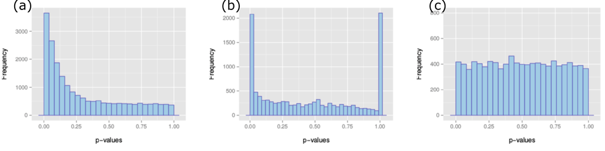

1. anti-conservative p-values (“Hooray!”)
2. very low counts genes usually have large p-values
3. do not expect positive tests after correction

## P-value histograms

Examples of unexpected overall distribution

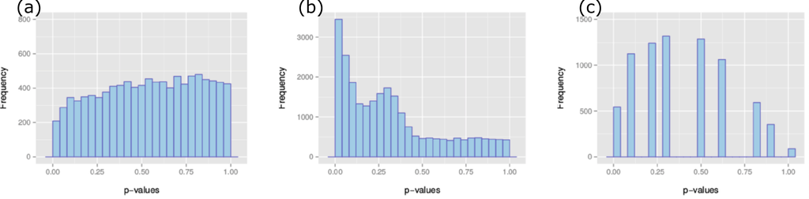

1. indicates a batch effect (confounding hidden variables)
2. the test statistics may be inappropriate (due to strong correlation structure for instance)
3. discrete distribution of p-values **!!!????!?!?!**

## MA plots and Volcano Plots

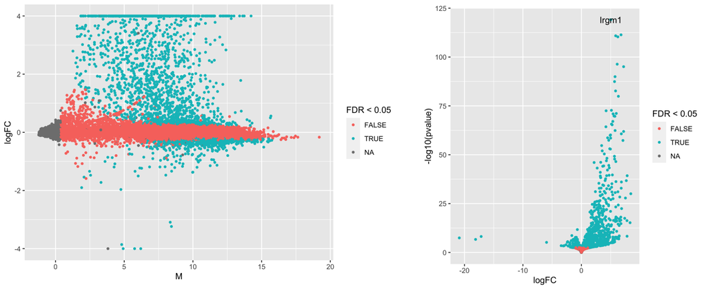

## Strip Charts for Specific Genes

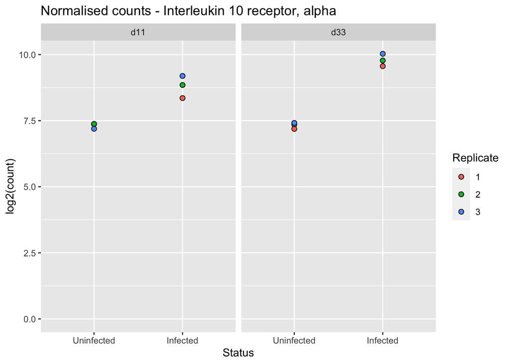

## Venn Diagram

- Venn diagram showing overlap between differentially expressed genes for different contrasts

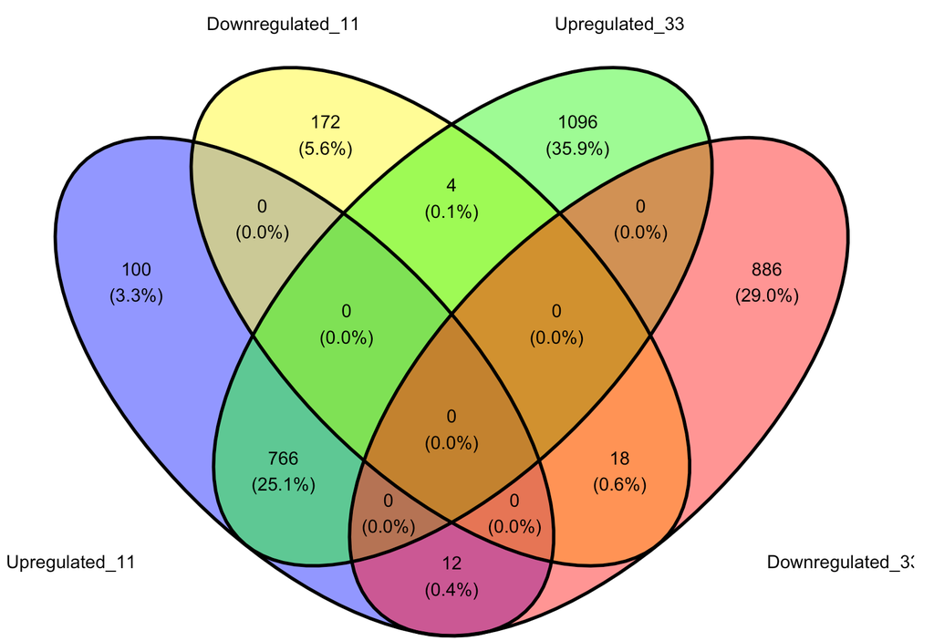

## Heatmaps

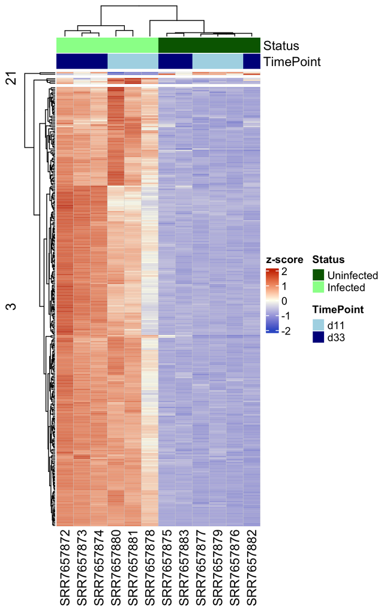

## Gene Coverage diagram

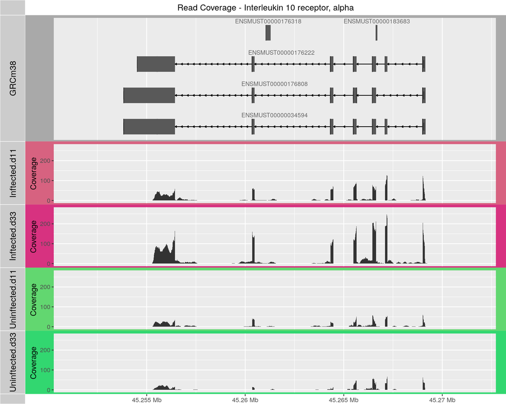